# Reproducible Research: Peer Assessment 1

Load necessary libraries:

```r
library(dplyr)
library(lattice)
```

## Loading and preprocessing the data

1. Extract the data if doesnt extracted and load:

```r
if(!file.exists("activity.csv")){
    unzip ("activity.zip", exdir = "./")
}
data<-read.csv("activity.csv")
```

2. Convert date column to Date Class:

```r
data$date<-as.Date(data$date)
```

## What is mean total number of steps taken per day?

1. Calculate the total number of steps taken per day

```r
stepsPerDay<-with(data, tapply(steps, date, sum))
```

2. Make a histogram of the total number of steps taken each day

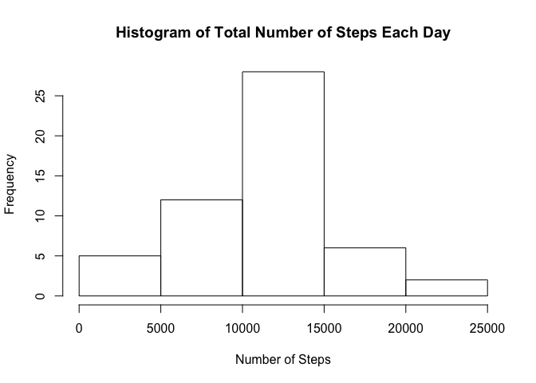

```r
hist(stepsPerDay, main="Histogram of Total Number of Steps Each Day", xlab="Number of Steps")
```

3. Mean and median of the total number of steps taken per day

```r
summary(stepsPerDay)[c("Mean","Median")]
```

```
##     Mean   Median
## 10766.19 10765.00
```

## What is the average daily activity pattern?

1. Make a time series plot (i.e. type=“l”) of the 5-minute interval (x-axis) and the average number of steps taken, averaged across all days (y-axis)

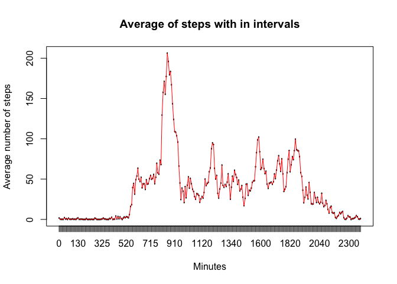

```r
stepsPer5Minutes<-with(data, tapply(steps, interval, mean, na.rm=TRUE))
stepsPer5Minutes<-as.data.frame.table(stepsPer5Minutes)
names(stepsPer5Minutes)<-c("Minutes", "Mean")
plot(stepsPer5Minutes$Minutes, stepsPer5Minutes$Mean, type="l", main="Average of steps with in intervals", xlab="Minutes", ylab="Average number of steps")
lines(stepsPer5Minutes$Minutes, stepsPer5Minutes$Mean, type="l", col="red")
```

2. The 5-minute interval that, on average, contains the maximum number of steps

```r
as.numeric(as.character(stepsPer5Minutes$Minutes))[which.max(stepsPer5Minutes$Mean)]
```

```
## [1] 835
```

## Imputing missing values

1. Total number of missing values in the dataset

```r
sum(is.na(data))
```

```
## [1] 2304
```

2. Missing values will be filled with average number of steps taken each 5-minute interval.

Get means of all 5 minutes interval which has missing value

```r
missingValues<-stepsPer5Minutes$Mean[stepsPer5Minutes$Minutes %in% data$interval[is.na(data$steps)]]
```

3. Create a new dataset with missing data filled

```r
filledData<-data.frame(data)
filledData$steps[is.na(filledData$steps)]<-missingValues
```

4. Make a histogram of the total number of steps taken each day and Calculate and report the mean and median total number of steps taken per day.

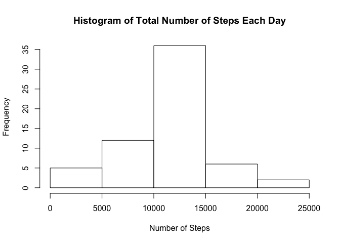

```r
stepsPerDay<-with(filledData, tapply(steps, date, sum))
hist(stepsPerDay, main="Histogram of Total Number of Steps Each Day", xlab="Number of Steps")
```

```r
summary(stepsPerDay)[c("Mean","Median")]
```

```
##     Mean   Median
## 10766.19 10766.19
```

Mean is not changed and median is slightly increased.

## Are there differences in activity patterns between weekdays and weekends?

1. Create a new factor variable in the dataset with two levels – “weekday” and “weekend” indicating whether a given date is a weekday or weekend day.

```r
filledData<-mutate(filledData, day_type =
    factor(case_when(weekdays(data$date)==c("Saturday", "Sunday") ~ "weekend", TRUE ~ "weekday")))
```

2. Make a panel plot containing a time series plot of the 5-minute interval (x-axis) and the average number of steps taken, averaged across all weekday days or weekend days (y-axis).

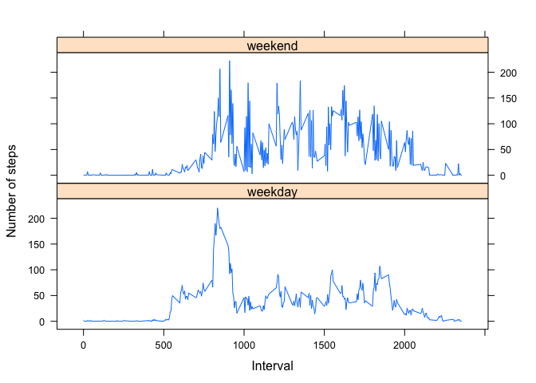

```r
filledData_interval_means <- aggregate(steps ~ interval + day_type, filledData, mean)
xyplot(steps ~ interval | day_type,
       data = filledData_interval_means,
       type = "l",
       xlab = "Interval",
       ylab ="Number of steps",
       layout=c(1,2))
```